# Projeto R - Analise estatístico de dataset

## Conteúdo

A Agência Nacional do Petróleo, Gás Natural e Biocombustíveis ( ANP ) divulga relatórios semanais dos preços do gás, diesel e outros combustíveis utilizados no transporte em todo o país. Esses conjuntos de dados trazem o valor médio por litro, número de postos de gasolina analisados e outras informações agrupadas por regiões e estados em todo o país.

Conforme dito anteriormente, esses conjuntos de dados são fornecidos pela ANP e são atualizados regularmente com novas datas e informações - que podem ser acessadas https://www.gov.br/anp/pt-br/assuntos/precos-e-defesa-da-concorrencia/precos/precos-revenda-e-de-distribuicao-combustiveis/serie-historica-do-levantamento-de-precos

- Importando as Bibliotecas:

```r
library(dplyr)
library(ggplot2)
library(purrr)
library (magrittr)
library(stringr)
library(tidyr)
library(readr)
```

- Fazendo a leitura do DataSet:

```r
dados <- read_csv2("C:/Users/Will/Desktop/linguagemR_TrabFinal/dataset_preco_gas_brasil.csv", col_names = TRUE)
```

- Apresentando os dados:

```r
dados
```

| DTINICIAL | DTFINAL | REGIAO | ESTADO | PRODUTO | NUMPOSTO | UNIMEDIDA | PRCMEDIOREV | DESVPADRAOREV | PRCMINREV | PRCMAXREV | MARGEMEDREV | COEFVARIACAO | PRCMEDISTR | DESVPADRADISTR | PRCMINDISTR | PRCMAXDISTR | COEFVARDISTR |
| --- | --- | --- | --- | --- | --- | --- | --- | --- | --- | --- | --- | --- | --- | --- | --- | --- | --- |
| 09/05/2004 | 15/05/2004 | CENTRO OESTE | DISTRITO FEDERAL | ETANOL HIDRATADO | 127 | R$/l | 1.288e+03 | 0.016 | 1.19 | 1.350e+02 | 0.463 | 0.012 | 0.825 | 0.11 | 0.4201 | 0.9666 | 0.133 |
| 09/05/2004 | 15/05/2004 | CENTRO OESTE | GOIAS | ETANOL HIDRATADO | 387 | R$/l | 1.162e+03 | 0.114 | 0.89 | 1.449e+03 | 0.399 | 0.098 | 0.763 | 0.088 | 0.5013 | 1.05 | 0.115 |
| 09/05/2004 | 15/05/2004 | CENTRO OESTE | MATO GROSSO | ETANOL HIDRATADO | 192 | R$/l | 1.389e+03 | 0.0969999999999999 | 1.18 | 1.760e+02 | 0.419 | 0.07 | 0.97 | 0.095 | 0.5614 | 1.161 | 0.098 |
| 09/05/2004 | 15/05/2004 | CENTRO OESTE | MATO GROSSO DO SUL | ETANOL HIDRATADO | 162 | R$/l | 1.262e+03 | 0.07 | 1.09 | 1.509e+03 | 0.432 | 0.055 | 0.83 | 0.119 | 0.5991 | 122.242 | 0.143 |
| 09/05/2004 | 15/05/2004 | NORDESTE | ALAGOAS | ETANOL HIDRATADO | 103 | R$/l | 1.181e+03 | 0.078 | 1.05 | 1.400e+01 | 0.24 | 0.066 | 0.941 | 0.077 | 0.7441 | 10.317 | 0.082 |
| 09/05/2004 | 15/05/2004 | NORDESTE | BAHIA | ETANOL HIDRATADO | 408 | R$/l | 1.383e+03 | 0.132 | 0.999 | 2.050e+02 | 0.426 | 0.095 | 0.957 | 0.128 | 0.5686 | 1.35 | 0.134 |
| 09/05/2004 | 15/05/2004 | NORDESTE | CEARA | ETANOL HIDRATADO | 278 | R$/l | 1.453e+03 | 0.218 | 1.03 | 1.950e+02 | 0.353 | 0.15 | 1.1 | 0.068 | 0.7332 | 1.294 | 0.062 |
| 09/05/2004 | 15/05/2004 | NORDESTE | MARANHAO | ETANOL HIDRATADO | 105 | R$/l | 1.631e+03 | 0.158 | 1.35 | 2.000e+01 | 0.515 | 0.0969999999999999 | 1.116 | 0.091 | 0.9923 | 136.183 | 0.082 |
| 09/05/2004 | 15/05/2004 | NORDESTE | PARAIBA | ETANOL HIDRATADO | 125 | R$/l | 1.284e+03 | 0.13 | 1.1 | 1.699e+03 | 0.353 | 0.1009999999999999 | 0.931 | 0.072 | 0.7577 | 12.972 | 0.077 |
| 09/05/2004 | 15/05/2004 | NORDESTE | PERNAMBUCO | ETANOL HIDRATADO | 423 | R$/l | 1.224e+03 | 0.141 | 0.989 | 1.700e+01 | 0.277 | 0.115 | 0.947 | 0.091 | 0.5643 | 13.541 | 0.096 |

[output cut: 990 more lines]

- Antes de começarmos a analisar os dados, vamos fazer a limpeza dos registros N/A, ajustar a coluna que vamos trabalhar para o tipo numérico e por fim filtrar apenas os registros não negativos.

```r
dados$PRCMEDISTR <- as.numeric(dados$PRCMEDISTR)
dados$PRCMEDISTR[dados$PRCMEDISTR == "NA"] <- NA
dados$PRCMEDISTR <- as.numeric(dados$PRCMEDISTR)
dados <- dados[complete.cases(dados$PRCMEDISTR), ]

dados <- dados %>%
  filter(PRCMEDISTR > 0)
```

- Adicionando uma nova coluna definida ‘como Margem de Lucro’

```r
dados %>%
  mutate(MARGEM_LUCRO = PRCMEDIOREV - PRCMEDISTR)
```

| DTINICIAL | DTFINAL | REGIAO | ESTADO | PRODUTO | NUMPOSTO | UNIMEDIDA | PRCMEDIOREV | DESVPADRAOREV | PRCMINREV | PRCMAXREV | MARGEMEDREV | COEFVARIACAO | PRCMEDISTR | DESVPADRADISTR | PRCMINDISTR | PRCMAXDISTR | COEFVARDISTR | MARGEM_LUCRO |
| --- | --- | --- | --- | --- | --- | --- | --- | --- | --- | --- | --- | --- | --- | --- | --- | --- | --- | --- |
| 09/05/2004 | 15/05/2004 | CENTRO OESTE | DISTRITO FEDERAL | ETANOL HIDRATADO | 127 | R$/l | 1.288e+03 | 0.016 | 1.19 | 1.350e+02 | 0.463 | 0.012 | 0.825 | 0.11 | 0.4201 | 0.9666 | 0.133 | 1.287175e+03 |
| 09/05/2004 | 15/05/2004 | CENTRO OESTE | GOIAS | ETANOL HIDRATADO | 387 | R$/l | 1.162e+03 | 0.114 | 0.89 | 1.449e+03 | 0.399 | 0.098 | 0.763 | 0.088 | 0.5013 | 1.05 | 0.115 | 1.161237e+03 |
| 09/05/2004 | 15/05/2004 | CENTRO OESTE | MATO GROSSO | ETANOL HIDRATADO | 192 | R$/l | 1.389e+03 | 0.0969999999999999 | 1.18 | 1.760e+02 | 0.419 | 0.07 | 0.970 | 0.095 | 0.5614 | 1.161 | 0.098 | 1.388030e+03 |
| 09/05/2004 | 15/05/2004 | CENTRO OESTE | MATO GROSSO DO SUL | ETANOL HIDRATADO | 162 | R$/l | 1.262e+03 | 0.07 | 1.09 | 1.509e+03 | 0.432 | 0.055 | 0.830 | 0.119 | 0.5991 | 122.242 | 0.143 | 1.261170e+03 |
| 09/05/2004 | 15/05/2004 | NORDESTE | ALAGOAS | ETANOL HIDRATADO | 103 | R$/l | 1.181e+03 | 0.078 | 1.05 | 1.400e+01 | 0.24 | 0.066 | 0.941 | 0.077 | 0.7441 | 10.317 | 0.082 | 1.180059e+03 |
| 09/05/2004 | 15/05/2004 | NORDESTE | BAHIA | ETANOL HIDRATADO | 408 | R$/l | 1.383e+03 | 0.132 | 0.999 | 2.050e+02 | 0.426 | 0.095 | 0.957 | 0.128 | 0.5686 | 1.35 | 0.134 | 1.382043e+03 |
| 09/05/2004 | 15/05/2004 | NORDESTE | CEARA | ETANOL HIDRATADO | 278 | R$/l | 1.453e+03 | 0.218 | 1.03 | 1.950e+02 | 0.353 | 0.15 | 1.100 | 0.068 | 0.7332 | 1.294 | 0.062 | 1.451900e+03 |
| 09/05/2004 | 15/05/2004 | NORDESTE | MARANHAO | ETANOL HIDRATADO | 105 | R$/l | 1.631e+03 | 0.158 | 1.35 | 2.000e+01 | 0.515 | 0.0969999999999999 | 1.116 | 0.091 | 0.9923 | 136.183 | 0.082 | 1.629884e+03 |
| 09/05/2004 | 15/05/2004 | NORDESTE | PARAIBA | ETANOL HIDRATADO | 125 | R$/l | 1.284e+03 | 0.13 | 1.1 | 1.699e+03 | 0.353 | 0.1009999999999999 | 0.931 | 0.072 | 0.7577 | 12.972 | 0.077 | 1.283069e+03 |
| 09/05/2004 | 15/05/2004 | NORDESTE | PERNAMBUCO | ETANOL HIDRATADO | 423 | R$/l | 1.224e+03 | 0.141 | 0.989 | 1.700e+01 | 0.277 | 0.115 | 0.947 | 0.091 | 0.5643 | 13.541 | 0.096 | 1.223053e+03 |

[output cut: 990 more lines]

### Logo abaixo começaremos a apresentação de alguns gráficos

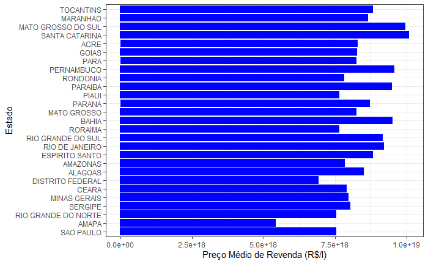

```r
ggplot(dados, aes(x = reorder(ESTADO, PRCMEDIOREV), y = PRCMEDIOREV)) +
  geom_col(fill = "blue") +
  coord_flip() +
  labs(x = "Estado", y = "Preço Médio de Revenda (R$/l)") +
  theme_bw()
```

- Variação do preço médio do produto ao longo do tempo em São Paulo

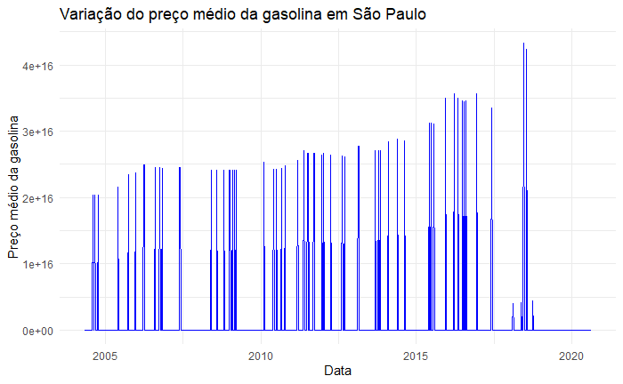

```r
dados %>%
  filter(PRODUTO == "GASOLINA COMUM" & ESTADO == "SAO PAULO") %>%
  mutate(DATA = as.Date(DTINICIAL, "%d/%m/%Y")) %>%
  ggplot(aes(x = DATA, y = PRCMEDIOREV)) +
  geom_line(color = "blue") +
  labs(x = "Data", y = "Preço médio da gasolina", title = "Variação do preço médio da gasolina em São Paulo") +
  theme_minimal()
```

- Preço medio ao longo do tempo

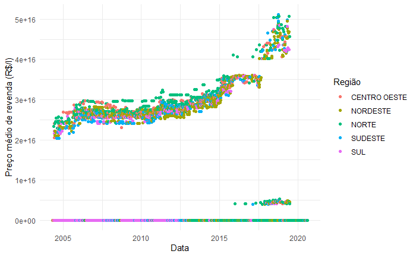

```r
dados %>%
  filter(PRODUTO == "GASOLINA COMUM") %>%
  select(DTINICIAL, REGIAO, PRCMEDIOREV) %>%
  mutate(DTINICIAL = as.Date(DTINICIAL, "%d/%m/%Y")) %>%
  ggplot(aes(x = DTINICIAL, y = PRCMEDIOREV, color = REGIAO)) +
  geom_jitter() +
  labs(x = "Data", y = "Preço médio de revenda (R$/l)",
       color = "Região") +
  theme_minimal()
```

- Preço médio de distribuição

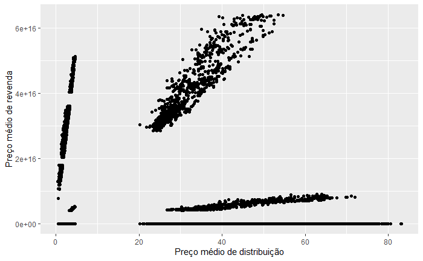

```r
ggplot(dados, aes(x = PRCMEDISTR, y = PRCMEDIOREV)) +
  geom_point() +
  labs(x = "Preço médio de distribuição", y = "Preço médio de revenda")
```

### criando o modelo para analise de regressão linear e plotando

```r
modelo <- lm(PRCMEDIOREV ~ PRCMEDISTR, data = dados)
summary(modelo)
```

```
Call:
lm(formula = PRCMEDIOREV ~ PRCMEDISTR, data = dados)

Residuals:
       Min         1Q     Median         3Q        Max
-2.376e+15 -1.992e+15 -1.987e+15 -1.984e+15  6.176e+16

Coefficients:
             Estimate Std. Error t value Pr(>|t|)
(Intercept) 1.976e+15  2.647e+13  74.626  < 2e-16 ***
PRCMEDISTR  4.822e+12  1.566e+12   3.078  0.00208 **
---
Signif. codes:  0 ‘***’ 0.001 ‘**’ 0.01 ‘*’ 0.05 ‘.’ 0.1 ‘ ’ 1

Residual standard error: 7.524e+15 on 111913 degrees of freedom
Multiple R-squared:  8.466e-05, Adjusted R-squared:  7.573e-05
F-statistic: 9.476 on 1 and 111913 DF,  p-value: 0.002082
```

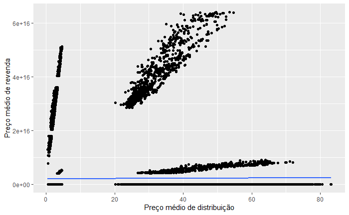

```r
ggplot(dados, aes(x = PRCMEDISTR, y = PRCMEDIOREV)) +
  geom_point() +
  geom_smooth(method = "lm", se = FALSE) +
  labs(x = "Preço médio de distribuição", y = "Preço médio de revenda")
```

- Previsão do modelo:

```r
novo_dado <- data.frame(PRCMEDISTR = 2.50)
previsao <- predict(modelo, newdata = novo_dado)
previsao
```

```
           1
1.987641e+15
```